# inlinehelp_view_study_parts_routing_en-us – IRTlib

#### Use of logical expressions

Conditions are also possible with variables of a different data type:

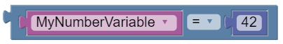

For technical reasons, it may also be necessary to check whether a variable has no value at all. This can be implemented by using the *blockly* component `null`:

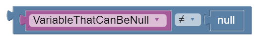

**Combination of logical expressions**: Individual conditions or logical expressions can be combined with the following *Blockly* element from the *Logic* section:

> An *and* and an *or* linking of the statements is available for selection. The *and* link is true if both expressions are true, the *or* link is true if at least one of the two expressions (or both expressions) is true.

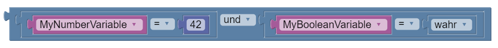

> Several *logical expressions* can be nested inside each other:

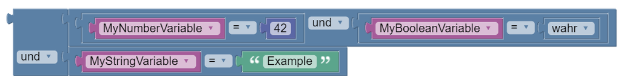

> Note: For a clearer display, the external display is selected for the external *and* link.

**Multiple conditions (*if* / *else*)**: By clicking on the small cogwheel symbol of a condition block (*if/make*), it can be configured:

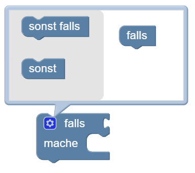

> By adding an *unless* section, a further condition can be added. The condition defined in an *if* section is checked if the previous conditions (*if*) are not fulfilled. If a condition is fulfilled, the defined *blockly* operators are executed.

**Check operator**: For value assignments depending on a condition, the *blockly* editor provides a special operator *check-if-true-if-false*:

> The operator combines a value assignment with a logical expression:

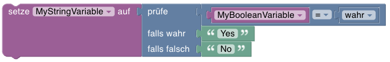

> In this example, the string variable `MyStringVariable` is assigned the value `Yes` if the boolean variable `MyBooleanVariable` has the value `true`. If `MyBooleanVariable` has the value `false`, `MyStringVariable` is assigned the value `No`.

(top)

#### Sequence control with loops

The multiple execution of *blockly* operators (and the actions that can be displayed with them) is possible with loops. The *Loops* section of the *Palette* contains the *Blockly* elements required for this.

**Repeat n times**: The following *Blockly* operator can be used to repeat the execution of blocks n times:

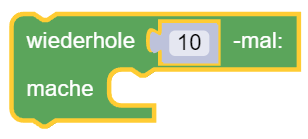

**Repeat as long as**: Loops can also be repeated *until* a condition is true (or *as long as* a condition is true):

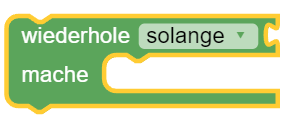

> Example:

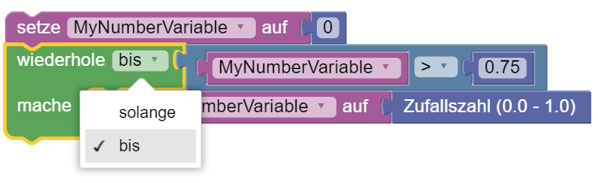

**Count from/to**: Loop with auxiliary variables:

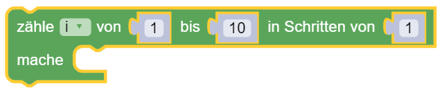

**For each value from list**: Loop over all values in a list:

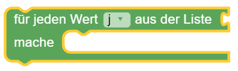

**Cancel loops prematurely**: The following *blockly* element can be used to cancel a loop (prematurely) or to start the next loop pass prematurely:

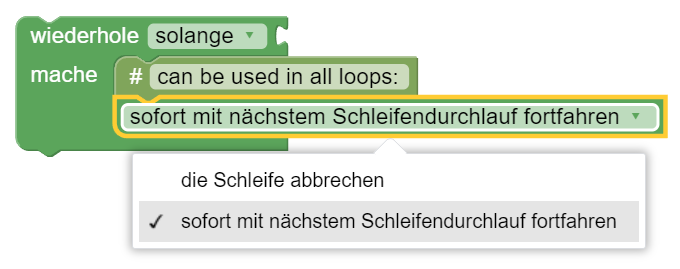

#### Operators for numbers and simple mathematical functions

The *Math* section of the *Palette* contains *Blockly* elements for using numbers and simple mathematical functions.

**Expressions**

**Basic functions**

- Addition, subtraction, multiplication, division and power function of two arguments:

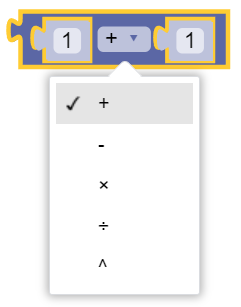

> Nesting is possible, e.g:

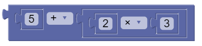

- Division with remainder:

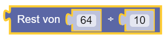

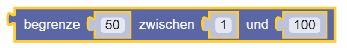

**Built-in functions**

- Trigonometric functions:

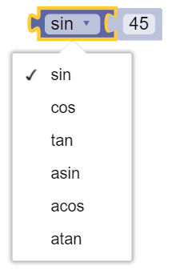

- Rounding of values:

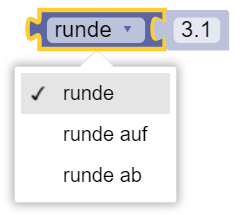

- Further functions:

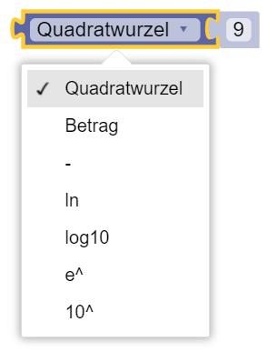

- Integers (in value range):

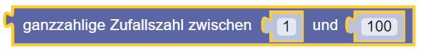

**Numeric functions for lists**: Predefined functions for lists include:

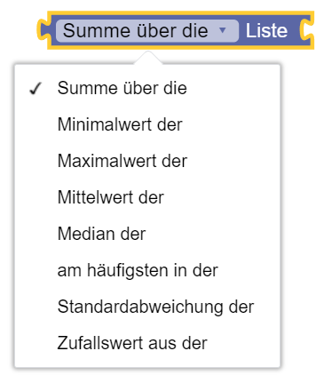

Notes:

- If required, further functions can be implemented with loops for lists.
- When using the functions, please note that the list function can only be used for lists with numerical data types!

(top)

#### Operators for text and simple string operations

The *Text* section of the *Palette* contains *Blockly* elements for using strings.

**Chains**: Various operators can be used to join text and assign it to variables:

- Append a text to a variable:

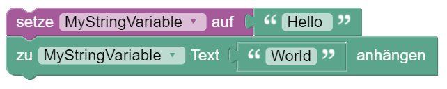

- Concatenate texts (and variable values) and pass them on to other *blockly* operators:

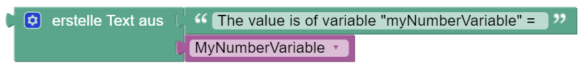

- Assign a variable to merged texts:

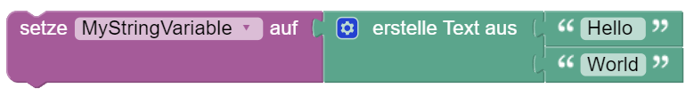

**Text length**: The length of a character string can be determined with the following *blockly* operator:

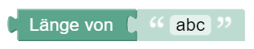

**Check for empty string**: Empty string variables can be recognised by the fact that the number of characters is $0$.

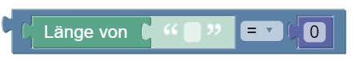

**Find position in string**: An operator that searches *in text* (passed by variable or as an expression) for the *first* or *last* *occurrence of a term* can be used as follows:

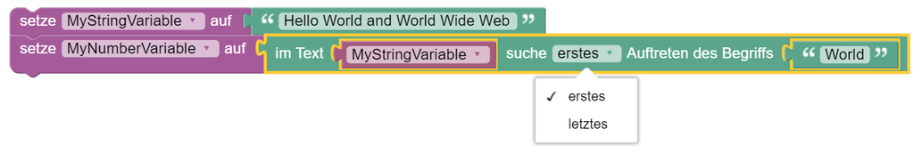

The position of the *term* within the character string (i.e. *in the text*) is returned.

**Form sub-strings**: The following operator takes the first letters from the transferred string *in text*. The number of letters is also passed.

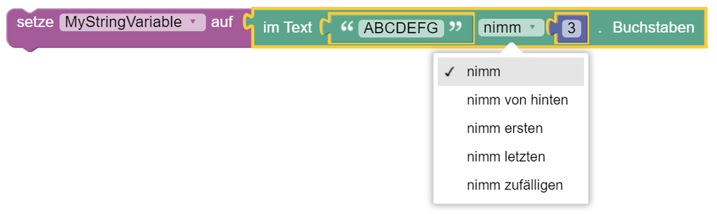

| letter function | parameter N | meaning |
| --- | --- | --- |
| take | Yes | The first N letters are returned |
| take from last | Yes | The last N letters are returned |
| take first | No | The first letter is returned (corresponds to take with N=1) |
| take last | No | The last letter is returned (corresponds to take from behind with N=1) |
| Take random | No | A random letter is returned |

Letters from a character string can also be extracted using the following operator and assigned to a variable, for example:

- Example (here, for example, characters 3 to 5 can be taken from a character string):

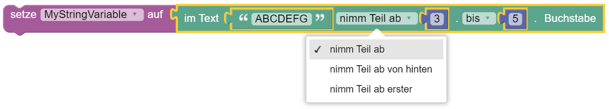

**Change texts**: Existing texts (either as expressions or from variables of *datatype* *string*) can be modified by applying operators.

- The following operator can be used to convert text to uppercase or lowercase:

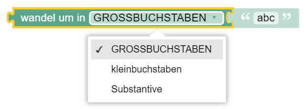

> The `nouns` option converts the passed string into a sequence of words with a capital initial letter (except for strings that are written entirely in capital letters).
- Leading, trailing or leading and trailing spaces can be removed using the following operator:

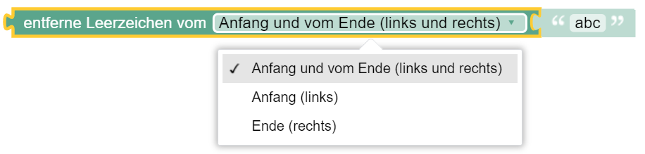

(top)

#### Operators for times and simple time operations

The *Date & Time* section of the *Palette* contains *Blockly* elements for using times within flow definitions.

**Fixing points in time**: Variables of the *datatype* *DateTime* can be assigned timestamps.

**Determine time differences**: Complete example: The following *Blockly* code measures the time for processing tasks 1 to 4. To do this, the start time is first recorded, and after the tasks have been processed, the time difference is determined and converted into seconds:

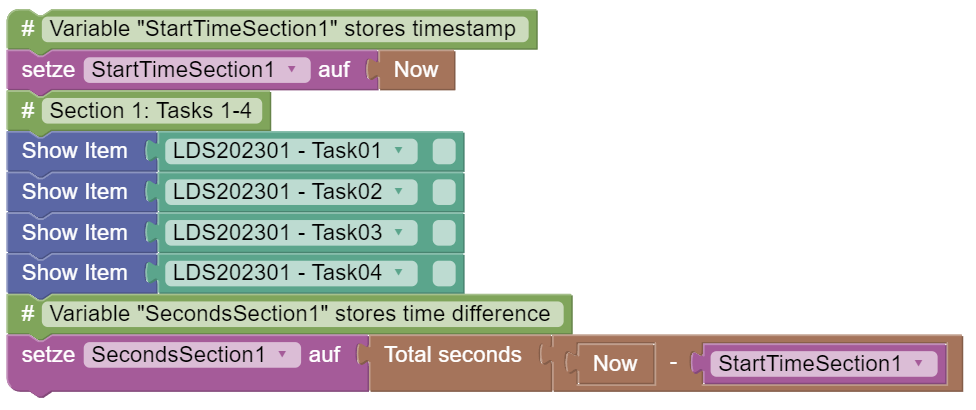

**Conversion of time measures**

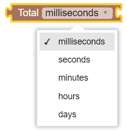

(top)

#### Operators for lists

The *Lists* section of the *Palette* contains *Blockly* elements for creating and using lists.

**Create list**: Various options are available for creating lists.

- Lists can be created from existing elements:

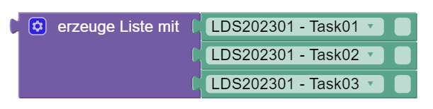

> The number of elements of the *create list with* operator can be configured using drag-and-drop after clicking on the *cogwheel* symbol:

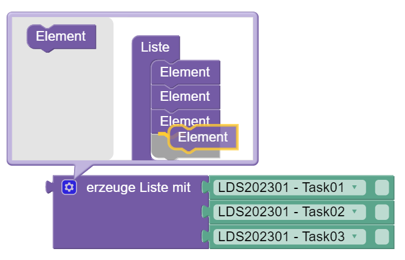

> When creating lists, please note that the *Blockly* editor does not check the data type. Lists with values of different data types can be created (incorrectly), but do not lead to a functioning test sequence.
- Lists can be created by repeating an element:

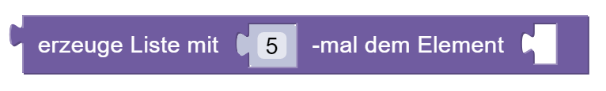

**Combining lists**: Existing lists can be merged with the following operator:

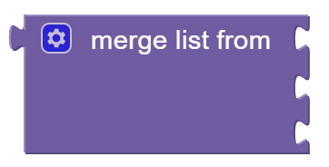

**Sublists**: A sublist can be selected from lists using the following operator:

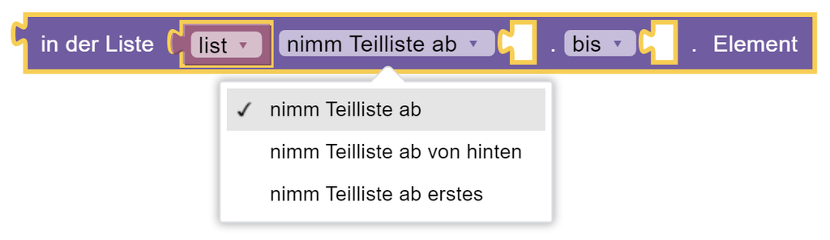

> Further operator options for *to*: *to from last* and *to last*.

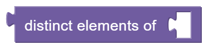

**Search and replace**: The following operators are available for searching and replacing elements in lists:

- The following operator finds elements in lists:

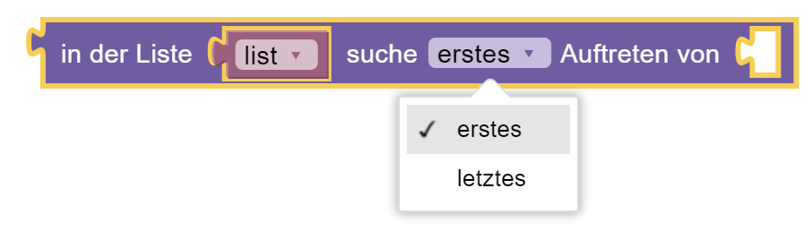

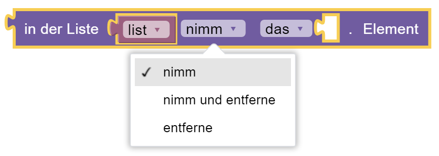

> Further options of the operator for *that*: *from behind that* / *first* / *last* and *random*.
- The following operator replaces and inserts in a list:

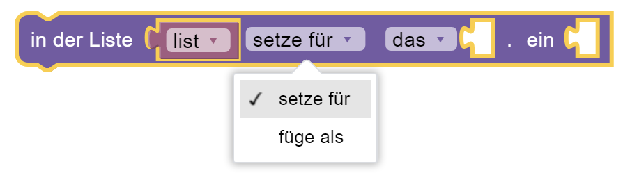

> Further options of the operator for *that*: *from behind that* / *first* / *last* and *random*.

**Conversion of lists and text**: List and text can be converted using separators.

- The following operator creates a text from a list or a list from a text:

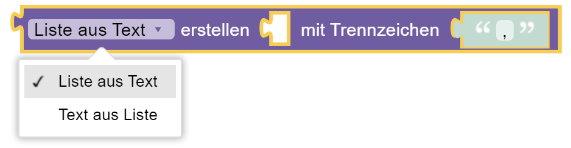

**Sort lists**: Elements in lists can also be sorted.

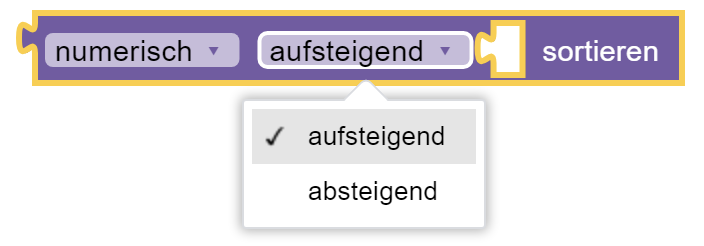

(top)